# PhD Project (RWE)

Code used for my PhD, in clinical epidemiology, project. The aim of this project is to determine if Z-drugs (zopiclone, etc.) are really worse than benzodiazepines (diazepam, lorazepam, etc.) with respect to adverse effects / events.

Currently a work in progress (WIP). This project is still in the brainstorming phase

## PICOS

The first step of developing a research project is to define the research question. To assist with this, PICOS criteria can be used to help refine the research question. For this project, PICOS are as follows:

- **P**opulation: Adults, defined as people 18 years of age or older
- **I**ntervention: Benzodiazepines (lorazepam, diazepam, etc.)
- **C**omparator: Z-drug (zopiclone, etc.)
- **O**utcome: Adverse Effect / Event (hip fracture, cognitive impairment, etc.)
- **S**tudy Design: Retrospective, longitudinal study using observational data

## Benzodiazepine and Hip Fractures: A Directed Acyclic Graph (DAG)

Another important step is to determine what variables are associated with the question of interest and how they are associated with each other. These variables were selected based upon a review of the literature and previous work for my MSc, in clinical epidemiology, project.

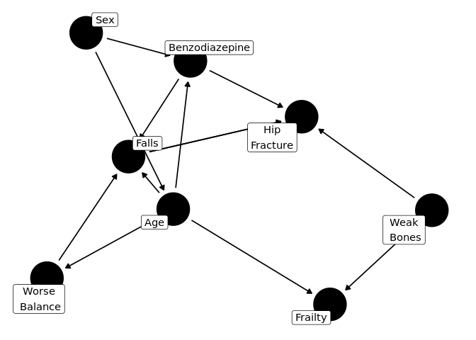